# Cultural Competence Matrix

A Visualization Framework for Public Health Access in Marginalized Populations

R · ggplot2 · health-equity diagnostics · transferable methods

▶ Launch the interactive app

## Overview

The Cultural Competence Matrix scores how accessible a health system is to a marginalized population across **six evidence-based domains**, then visualizes where access breaks down. The framework is population-agnostic; it is illustrated here with a documented field case — the Malayali of the Sitheri Hills, Tamil Nadu (author's MA Medical Anthropology dissertation) — alongside illustrative comparison populations.

| Domain | Cultural-competence level (Betancourt) | Access type (Andersen) |
| --- | --- | --- |
| D1 · Organizational Representation | Organizational | Capacity |
| D2 · Structural Access & Competency | Structural / upstream | Capacity |
| D3 · Language & Communication Fit | Structural ↔ Clinical | Capacity |
| D4 · Trust & Therapeutic Relationship | Clinical | Realized |
| D5 · Perceived Respect & Dignity | Clinical | Realized |
| D6 · Pluralistic Care-Seeking | Behavioral | Realized |

Each cell is scored on an ordinal 0–3 scale (0 = absent/hostile, 3 = strong/concordant).

## 1 · Scored matrix heatmap

Six domains across populations — the hero view.

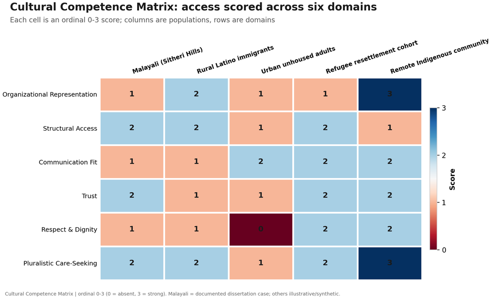

Malayali = documented dissertation case; other populations are illustrative/synthetic.

## 2 · Access profiles (radar)

The *shape* of access — the documented case vs. an illustrative contrast that inverts it.

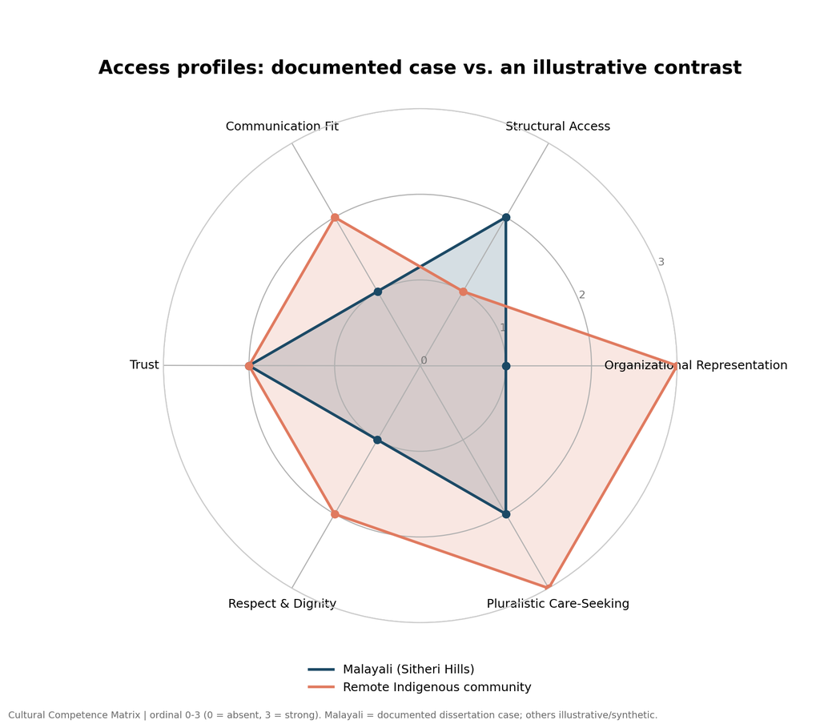

## 3 · The conversion gap

Does built capacity become dignified use? (Andersen: potential vs. realized access.)

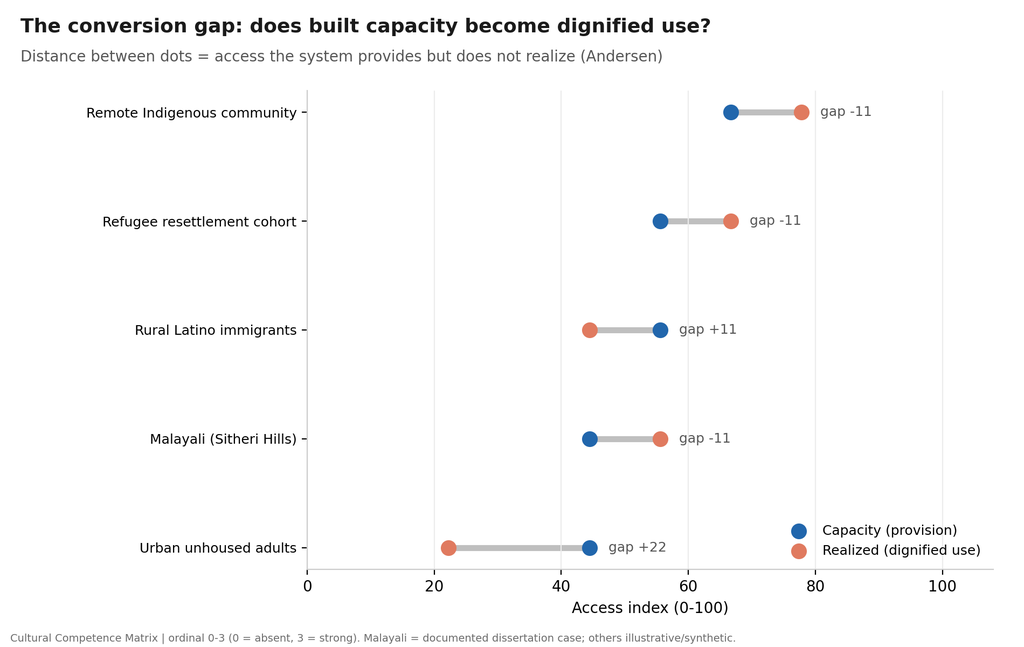

## 4 · Medical pluralism in transition

A case-specific view: ethnomedicine contracts as the Primary Health Centre embeds.

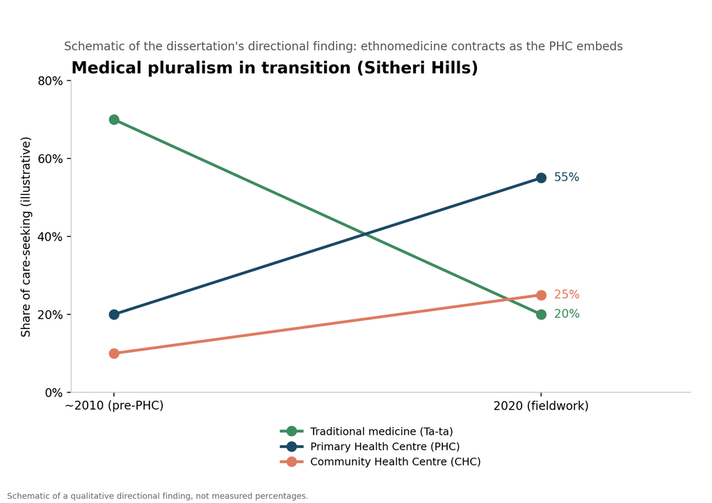

Schematic of a qualitative directional finding, not measured percentages.

## Theoretical grounding

Domains draw on peer-reviewed literature: Betancourt et al.'s tri-level model of cultural competence ([organizational / structural / clinical](https://doi.org/10.1093/phr/118.4.293)), the Cochrane review of cultural-competence education ([Horvat et al.](https://doi.org/10.1002/14651858.CD009405.pub2)), language-concordance evidence ([Diamond et al.](https://doi.org/10.1007/s11606-019-04847-5)), structural competency ([Malone et al.](https://doi.org/10.1037/pst0000557)), medical mistrust ([Dong et al.](https://doi.org/10.1016/j.pec.2026.109678)), and pluralistic care-seeking ([Chowdhury et al.](https://doi.org/10.1186/1471-2431-11-88)), with Andersen's Behavioral Model framing the capacity-vs-realized split.

**Data availability.** The scored dataset is private and held by the author. Comparison-population figures are illustrative/synthetic. To request the data, contact **Kamalakanta Gahan** · kgahan.duke@gmail.com.